# Analyse des données génomiques

31 mai, 2022

## Objectifs

- **Acquérir des compétences d’analyse de données génomiques**
  - Méthodes (normalisation, tests à l’effet du génome, contrôle des faux positifs)
  - Démarches (comment choisir une méthode d’analyse ?)
- **Se familiariser avec R et Rstudio**
  - Mettre en oeuvre (limma, DESeq2)
  - Editer des rapports (Rmarkdown)

**Modalités pédagogiques**

- Apprentissage par mise en situation (tutoriel)
- Programme modulable selon questions

## Environnement R et Rstudio

## R

: environnement pour l’analyse de données et la visualisation

- R est un logiciel libre
- Site web : https://www.r-project.org
- Nov. 2021 : > 18 000 packages https://cran.r-project.org/
- Communautés R :
  - https://www.r-bloggers.com/,
  - https://rladies.org/,
  - https://r-toulouse.netlify.app/
  - https://stackoverflow.com/questions/
  - https://r-graph-gallery.com/

## Rstudio

[figure not shown]

: interface pour R (IDE : Integrated Development Environment)

- Site web : https://www.rstudio.com/
- Environnement ergonomique pour l’analyse de données
- Outils pour l’édition de rapport d’études
  - Rmarkdown : http://rmarkdown.rstudio.com/
- Préparation de la session de travail
  - Créez un projet pour l’analyse des données RNA-seq

## Plan

- 1 - Données RNA-seq
- 2 - Tests à l’échelle du génome
  - 2.1 - Normalisation des données
  - 2.2 - Modèles pour données de comptage
  - 2.3 - Transformation des données
- 3 - Sélection de gènes

## 1 - Données RNA-seq

## Importer des données

Nombres de *reads* par gène et par échantillon:

```r
rawdta <- read.table("DataTest_foie_15ind_4cat4ind_10742genes_countData.txt",
                      sep="\t",header=TRUE,stringsAsFactors=TRUE)
head(rawdta[,1:6],n=3) %>% kbl(caption="Extrait des données") %>%
  kable_paper(bootstrap_options = "striped", full_width = F)
```

Extrait des données

|  | F10_G_B | F11_M_H | F13_G_H | F14_M_H | F15_G_B | F16_M_B |
| --- | --- | --- | --- | --- | --- | --- |
| CD69 | 124 | 149 | 210 | 339 | 161 | 352 |
| GOLGB1 | 1918 | 2002 | 2052 | 2478 | 1639 | 2374 |
| HCLS1 | 745 | 392 | 1250 | 817 | 901 | 813 |

## Dimensions

**Gènes** :

```r
nbgenes <- nrow(rawdta) ; nbgenes
```

```
[1] 10742
```

**Echantillons** :

```r
nbsamples <- ncol(rawdta) ; nbsamples
```

```
[1] 15
```

```r
sample_labs <- colnames(rawdta) ; head(sample_labs)
```

```
[1] "F10_G_B" "F11_M_H" "F13_G_H" "F14_M_H" "F15_G_B" "F16_M_B"
```

## Plan d’expérience

Deux lignées x deux régimes :

```r
genotype <- factor(substring(sample_labs,first=5,last=5))
diet <- factor(substring(sample_labs,first=7,last=7))
covariates <- data.frame(Genotype=genotype,Diet=diet)
rownames(covariates) <- colnames(rawdta)
summary(covariates)
```

```
 Genotype Diet
 G:8      B:7
 M:7      H:8
```

## 2 - Tests à l’échelle du génome

## Sélection de gènes

**Objectif** : identifier les gènes dont l’expression moyenne dépend des conditions expérimentales (lignée, régime, …)

**Méthode** : tests d’un même effet sur chaque gène

## Exemple du gène LPCAT3

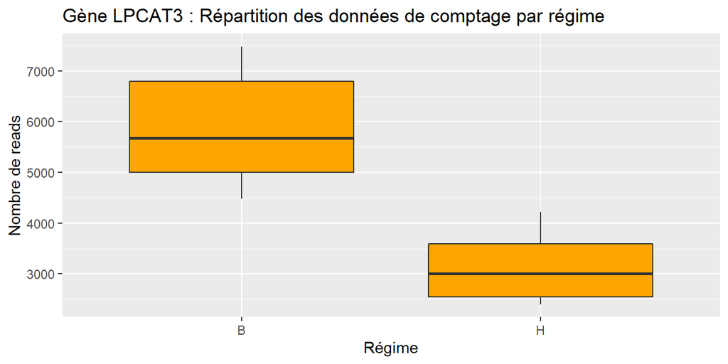

```r
df <- data.frame(LPCAT3=as.matrix(rawdta)["LPCAT3",],Diet=covariates$Diet)
df %>% ggplot() + geom_boxplot(aes(x=Diet,y=LPCAT3),fill="orange") +
  ggtitle("Gène LPCAT3 : Répartition des données de comptage par régime") +
  xlab("Régime") + ylab("Nombre de reads")
```

## Test sur un gène : analyse de la variance

Modèle : \(Y_{ij} = \mu + \alpha_{i} + \epsilon_{ij}\)

où

- \(Y_{ij}\) : nombre de *reads* pour un gène dans le \(j\)ème échantillon du groupe \(i\) (régime B ou H)
- \(\mu\) : expression moyenne dans le groupe 1 (régime B)
- \(\alpha_2\) (fold-change) : différence d’expressions moyennes entre groupes 1 et 2
- \(\epsilon_{ij}\) suit une loi normale d’écart-type \(\sigma\)

## Test de Fisher

**Test pour le gène LPCAT3**

```r
dta <- data.frame(y=as.matrix(rawdta)["LPCAT3",],Diet=covariates$Diet)
mod0 <- lm(y~1,data=dta)
mod1 <- lm(y~Diet,data=dta)
anova(mod0,mod1) %>% kbl(caption="Table d'analyse de la variance") %>%
  kable_paper(bootstrap_options = "striped", full_width = F)
```

Table d’analyse de la variance

| Res.Df | RSS | Df | Sum of Sq | F | Pr(>F) |
| --- | --- | --- | --- | --- | --- |
| 14 | 40749971 | NA | NA | NA | NA |
| 13 | 12694191 | 1 | 28055780 | 28.7 | 0 |

- **Signal biologique** : **Sum of Sq**
- **Bruit** : **RSS**

## Effet à l’échelle du génome

**Test pour tous les gènes**

```r
my_ftest <- function(y,groupe) {
   mod0 <- lm(y~1,data=data.frame(y=y,Groupe=groupe))
   mod1 <- lm(y~Groupe,data=data.frame(y=y,Groupe=groupe))
   anova(mod0,mod1)[2,"Pr(>F)"]
}
pval_Fisher <- apply(X=rawdta,MARGIN=1,FUN=my_ftest,groupe=covariates$Diet)
pval_Fisher["LPCAT3"]
```

```
 LPCAT3
0.00013
```

## Répartition des p-values

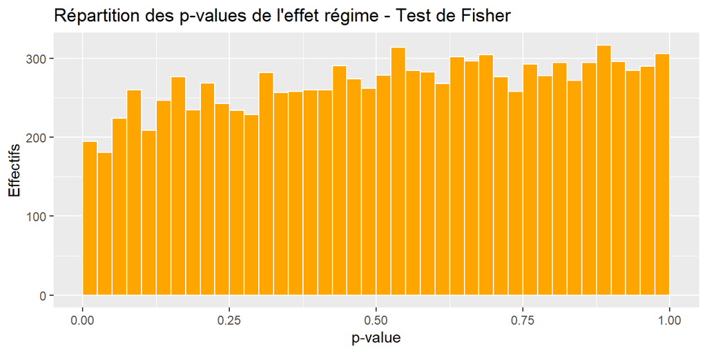

```r
data.frame(Pval=pval_Fisher) %>% ggplot() + aes(x = Pval) +
  geom_histogram(fill="orange",bins=15,col="white",breaks=seq(from=0,to=1,by=0.025)) +
  ggtitle("Répartition des p-values de l'effet régime - Test de Fisher") +
  xlab("p-value") + ylab("Effectifs")
```

## Identification des gènes positifs

**Combien de gènes positifs ?**

```r
positives_Fisher <- pval_Fisher<=0.05
select <- which(positives_Fisher)
length(select)
```

```
[1] 376
```

**Combien de gènes positifs si l’expression moyenne de tous les gènes était la même dans les deux régimes ?**

## Hétérogénéité des données RNA-seq

**Sources d’hétérogénéité**

- **Variations technologiques** :
- profondeur de séquençage (comparaison entre groupes d’échantillons),
- longueur des gènes (comparaison des expressions de différents gènes)

**\(\Rightarrow\) Normalisation**

- **Nature des données de comptage** : \(\sigma^{2} = f(\mu_{i})\).

**\(\Rightarrow\) Choix d’un modèle adapté à la relation entre signal et bruit**

## 2.1 - Normalisation des données

## Méthode Median of ratios (1/5, package DESeq2)

**Nombre de reads pour un pseudo-échantillon de référence**

```r
prs <- exp(rowMeans(log(rawdta)))
head(cbind(rawdta[,1:6],PRS=prs),n=3) %>%
  kbl(caption="Extrait des données avec PRS") %>%
  kable_paper(bootstrap_options = "striped", full_width = F)
```

Extrait des données avec PRS

|  | F10_G_B | F11_M_H | F13_G_H | F14_M_H | F15_G_B | F16_M_B | PRS |
| --- | --- | --- | --- | --- | --- | --- | --- |
| CD69 | 124 | 149 | 210 | 339 | 161 | 352 | 178 |
| GOLGB1 | 1918 | 2002 | 2052 | 2478 | 1639 | 2374 | 1921 |
| HCLS1 | 745 | 392 | 1250 | 817 | 901 | 813 | 851 |

## Méthode Median of ratios (2/5, package DESeq2)

**Ratios au pseudo-échantillon de référence**

```r
ratios_to_prs <- rawdta/tcrossprod(prs,rep(1,nbsamples))
head(ratios_to_prs[,1:6],n=3) %>%
  kbl(caption="Extrait des ratios au PRS") %>%
  kable_paper(bootstrap_options = "striped", full_width = F)
```

Extrait des ratios au PRS

|  | F10_G_B | F11_M_H | F13_G_H | F14_M_H | F15_G_B | F16_M_B |
| --- | --- | --- | --- | --- | --- | --- |
| CD69 | 0.698 | 0.839 | 1.18 | 1.91 | 0.907 | 1.982 |
| GOLGB1 | 0.999 | 1.042 | 1.07 | 1.29 | 0.853 | 1.236 |
| HCLS1 | 0.875 | 0.460 | 1.47 | 0.96 | 1.058 | 0.955 |

## Méthode Median of ratios (3/5, package DESeq2)

**Facteurs de normalisation par échantillon**

```r
norm_factors <- apply(X=ratios_to_prs,MARGIN=2,FUN=median,na.rm=TRUE)
head(norm_factors) %>% t() %>%
  kbl(caption="Facteurs de normalisation") %>%
  kable_paper(bootstrap_options = "striped", full_width = F)
```

Facteurs de normalisation

| F10_G_B | F11_M_H | F13_G_H | F14_M_H | F15_G_B | F16_M_B |
| --- | --- | --- | --- | --- | --- |
| 0.931 | 0.698 | 1.01 | 1.23 | 1.25 | 1.3 |

## Méthode Median of ratios (4/5, package DESeq2)

**Données de comptage normalisées**

```r
norm_dta <- rawdta/tcrossprod(rep(1,nbgenes),norm_factors)
head(norm_dta[,1:6],n=3) %>%
  kbl(caption="Données de comptage normalisées") %>%
  kable_paper(bootstrap_options = "striped", full_width = F)
```

Données de comptage normalisées

|  | F10_G_B | F11_M_H | F13_G_H | F14_M_H | F15_G_B | F16_M_B |
| --- | --- | --- | --- | --- | --- | --- |
| CD69 | 133 | 214 | 208 | 275 | 128 | 270 |
| GOLGB1 | 2060 | 2870 | 2033 | 2013 | 1308 | 1823 |
| HCLS1 | 800 | 562 | 1238 | 664 | 719 | 624 |

## Méthode Median of ratios (5/5, package DESeq2)

**Normalisation par le package DESeq2**

```r
dds <- DESeqDataSetFromMatrix(countData = rawdta,colData = covariates,design = ~ Diet)
dds <- estimateSizeFactors(dds)
norm_dta_deseq2 <- counts(dds, normalized=TRUE)
norm_dta_deseq2 <- round(norm_dta_deseq2)
head(norm_dta_deseq2[,1:6],n=3) %>%
  kbl(caption="Données de comptage normalisées (DESeq2)") %>%
  kable_paper(bootstrap_options = "striped", full_width = F)
```

Données de comptage normalisées (DESeq2)

|  | F10_G_B | F11_M_H | F13_G_H | F14_M_H | F15_G_B | F16_M_B |
| --- | --- | --- | --- | --- | --- | --- |
| CD69 | 134 | 215 | 209 | 277 | 129 | 272 |
| GOLGB1 | 2070 | 2887 | 2045 | 2025 | 1315 | 1833 |
| HCLS1 | 804 | 565 | 1246 | 668 | 723 | 628 |

## Effet à l’échelle du génome (données normalisées)

**Test pour tous les gènes**

```r
pval_Fisher <- apply(X=norm_dta_deseq2,MARGIN=1,FUN=my_ftest,groupe=covariates$Diet)
pval_Fisher["LPCAT3"]
```

```
  LPCAT3
1.63e-07
```

## Répartition des p-values

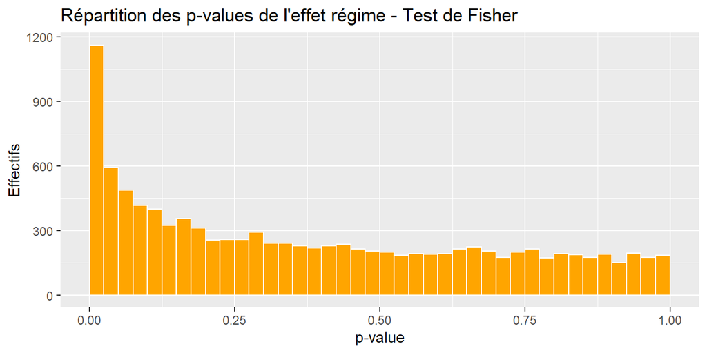

```r
data.frame(Pval=pval_Fisher) %>% ggplot() + aes(x = Pval) +
  geom_histogram(fill="orange",bins=15,col="white",breaks=seq(from=0,to=1,by=0.025)) +
  ggtitle("Répartition des p-values de l'effet régime - Test de Fisher") +
  xlab("p-value") + ylab("Effectifs")
```

## Identification des gènes positifs

**Combien de gènes positifs ?**

```r
positives_Fisher <- pval_Fisher<=0.05
select <- which(positives_Fisher)
length(select)
```

```
[1] 1756
```

## 2.2 - Modèles pour données de comptage

## Rapport entre signal biologique et bruit

**Rapport signal-bruit**

```r
my_wb_sd <- function(y,groupe) {
   mod0 <- lm(y~1,data=data.frame(y=y,Groupe=groupe))
   mod1 <- lm(y~Groupe,data=data.frame(y=y,Groupe=groupe))
   anova_tab <- anova(mod0,mod1)
   within_sd <- sqrt(anova_tab[2,"RSS"]/anova_tab[2,"Res.Df"])
   between_sd <- sqrt(anova_tab[2,"Sum of Sq"]/anova_tab[2,"Df"])
   return(list(Wsd=within_sd,Bsd=between_sd))
}
wb_sd <- apply(X=norm_dta_deseq2,MARGIN=1,FUN=my_wb_sd,groupe=covariates$Diet)
unlist(wb_sd["LPCAT3"])
```

```
LPCAT3.Wsd LPCAT3.Bsd
       481       4854
```

## Hétérogénéité à l’échelle du génome

**Rapport signal-bruit**

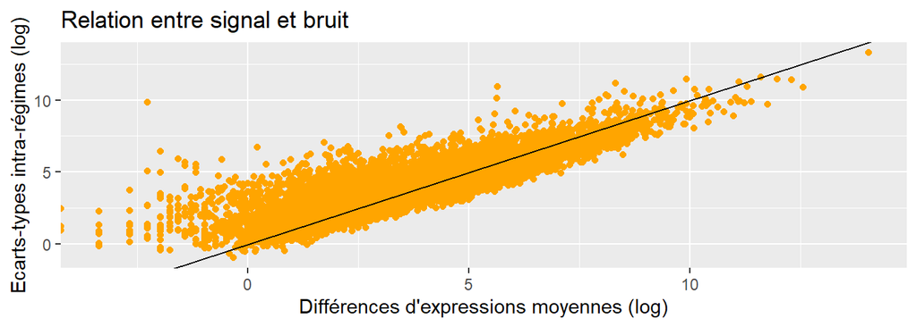

```r
w_sd <- unlist(lapply(wb_sd,function(x) x$Wsd))
b_sd <- unlist(lapply(wb_sd,function(x) x$Bsd))
data.frame(w_sd,b_sd) %>% ggplot() + xlab("Différences d'expressions moyennes (log)") +
  ylab("Ecarts-types intra-régimes (log)") +
  geom_point(aes(x=log(b_sd),y=log(w_sd)),col="orange") +
  ggtitle("Relation entre signal et bruit") + geom_abline(intercept=0,slope=1)
```

## Modèle pour données de comptage

**Modèle de Poisson d’analyse de la variance à un facteur** : \(Y_{ij} \sim {\cal P} ( \lambda_{i} )\)

où, pour un gène,

- \(Y_{ij}\) est le nombre de *reads* dans le \(j\)ème échantillon du groupe \(i\)
- \(\log ( \lambda_{i} ) = \mu + \alpha_{i}\)
- \(\mu\) : log-expression moyenne dans le groupe 1 (régime B)
- \(\alpha_2\) (log-fold-change) : log-ratio d’expressions moyennes entre groupes 1 et 2

**Propriété** : \(Var(Y_{ij}) = \lambda_{i}\)

## Sur-dispersion

**Relation variance-moyenne** : \(Var(Y_{ij}) \geq \lambda_{i}\)

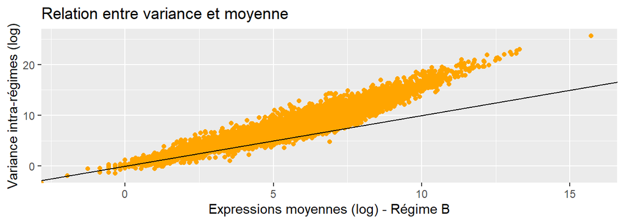

```r
mu_B <- rowMeans(norm_dta_deseq2[,covariates$Diet=="B"])
v_B <- apply(X=norm_dta_deseq2[,covariates$Diet=="B"],MARGIN = 1,FUN=var)
data.frame(Mean=mu_B,Var=v_B) %>% ggplot() +
  xlab("Expressions moyennes (log) - Régime B") + ylab("Variance intra-régimes (log)") +
  geom_point(aes(x=log(Mean),y=log(Var)),col="orange") +
  ggtitle("Relation entre variance et moyenne") + geom_abline(intercept=0,slope=1)
```

## Test d’analyse de la déviance

**Test de \(\chi^{2}\) pour le gène LPCAT3**

```r
dta <- data.frame(y=norm_dta_deseq2["LPCAT3",],Diet=covariates$Diet)
mod0 <- glm(y~1,data=dta,family="poisson")
mod1 <- glm(y~Diet,data=dta,family="poisson")
anova(mod0,mod1,test="Chisq") %>% kbl(caption="Table d'analyse de la déviance") %>%
  kable_paper(bootstrap_options = "striped", full_width = F)
```

Table d’analyse de la déviance

| Resid. Df | Resid. Dev | Df | Deviance | Pr(>Chi) |
| --- | --- | --- | --- | --- |
| 14 | 6130 | NA | NA | NA |
| 13 | 676 | 1 | 5454 | 0 |

- **Signal biologique** : **Deviance**
- **Bruit** : **Resid. Dev**

## Effet régime à l’échelle du génome

**Test pour tous les gènes**

```r
my_chi2_test <- function(y,groupe) {
   dta <- data.frame(y=y,Groupe=groupe)
   mod0 <- glm(y~1,data=dta,family="poisson")
   mod1 <- glm(y~Groupe,data=dta,family="poisson")
   anova(mod0,mod1,test="Chisq")[2,"Pr(>Chi)"]
}
pval_Poisson <- apply(X=norm_dta_deseq2,MARGIN=1,FUN=my_chi2_test,groupe=covariates$Diet)
pval_Poisson["LPCAT3"]
```

```
LPCAT3
     0
```

## Répartition des p-values

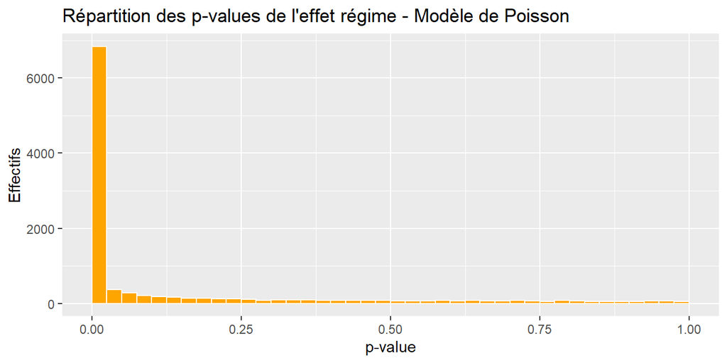

```r
data.frame(Pval=pval_Poisson) %>% ggplot() + aes(x = Pval) +
  geom_histogram(fill="orange",bins=15,col="white",breaks=seq(from=0,to=1,by=0.025)) +
  ggtitle("Répartition des p-values de l'effet régime - Modèle de Poisson") +
  xlab("p-value") + ylab("Effectifs")
```

## Identification des gènes positifs

**Combien de gènes positifs ?**

```r
positives_Poisson <- pval_Poisson<=0.05
select <- which(pval_Poisson<=0.05)
length(select)
```

```
[1] 7219
```

**Concordance Fisher-Poisson**

```r
table(positives_Fisher,positives_Poisson)
```

```
                positives_Poisson
positives_Fisher FALSE TRUE
           FALSE  3519 5466
           TRUE      3 1753
```

## Modèle pour données de comptage sur-dispersées

**Modèle Binomial Négatif d’analyse de la variance** : \(Y_{ij} \sim {\cal NB} ( \mu_{i} , \theta )\)

où, pour un gène,

- \(Y_{ij}\) est le nombre de *reads* dans le \(j\)ème échantillon du groupe \(i\)
- \(\log ( \mu_{i} ) = \mu + \alpha_{i}\)
- \(\mu\) : log-expression moyenne dans le groupe 1 (régime B)
- \(\alpha_2\) (log-fold-change) : log-ratio d’expressions moyennes entre groupes 1 et 2
- \(\theta\) : paramètre de dispersion

**Propriété** : \(Var (Y_{ij}) = \mu_{i} + \frac{\mu_{i}^2}{\theta}\)

## Test du rapport de vraisemblance

**Test de \(\chi^{2}\) pour le gène LPCAT3**

```r
dta <- data.frame(y=norm_dta_deseq2["LPCAT3",],Diet=covariates$Diet)
mod0 <- glm.nb(y~1,data=dta)
mod1 <- glm.nb(y~Diet,data=dta)
anova(mod0,mod1,test="Chisq") %>% kbl(caption="Test du rapport de vraisemblance") %>%
  kable_paper(bootstrap_options = "striped", full_width = F)
```

Test du rapport de vraisemblance

| Model | theta | Resid. df | 2 x log-lik. | Test | df | LR stat. | Pr(Chi) |
| --- | --- | --- | --- | --- | --- | --- | --- |
| 1 | 10.6 | 14 | -257 |  | NA | NA | NA |
| Diet | 93.0 | 13 | -225 | 1 vs 2 | 1 | 32.7 | 0 |

- **Signal biologique** : **LR stat.**
- **Bruit** : **-2 x log-lik.**

## Effet régime à l’échelle du génome

**Test pour tous les gènes**

```r
my_chi2_test <- function(y,groupe) {
   dta <- data.frame(y=y,Groupe=groupe)
   mod0 <- glm.nb(y~1,data=dta)
   mod1 <- glm.nb(y~Groupe,data=dta)
   anova(mod0,mod1,test="Chisq")[2,"Pr(Chi)"]
}
pval_nb <- apply(X=norm_dta_deseq2,MARGIN=1,FUN=my_chi2_test,groupe=covariates$Diet)
pval_nb["LPCAT3"]
```

```
  LPCAT3
1.06e-08
```

## Répartition des p-values

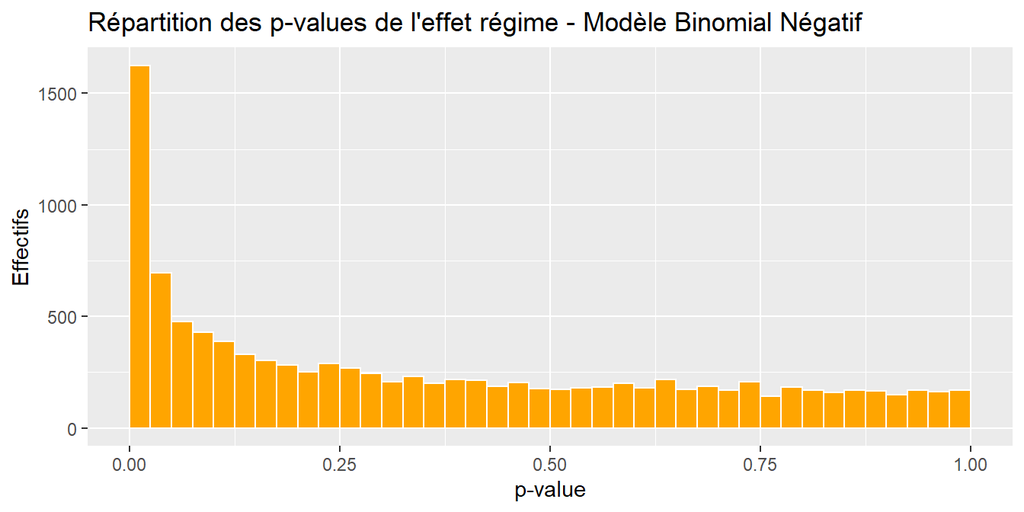

```r
data.frame(Pval=pval_nb) %>% ggplot() + aes(x = Pval) +
  geom_histogram(fill="orange",bins=15,col="white",breaks=seq(from=0,to=1,by=0.025)) +
  ggtitle("Répartition des p-values de l'effet régime - Modèle Binomial Négatif") +
  xlab("p-value") + ylab("Effectifs")
```

## Identification des gènes positifs

**Combien de gènes positifs ?**

```r
positives_nb <- pval_nb <= 0.05
select <- which(positives_nb)
length(select)
```

```
[1] 2321
```

**Concordance Fisher - Binomial Négatif**

```r
table(positives_Fisher,positives_nb)
```

```
                positives_nb
positives_Fisher FALSE TRUE
           FALSE  8415  571
           TRUE      6 1750
```

## Tests à l’échelle du génome avec DESeq2 (1/3)

```r
dds <- DESeq(dds)
res <- results(dds)
mcols(res)$description
```

```
[1] "mean of normalized counts for all samples" "log2 fold change (MLE): Diet H vs B"
[3] "standard error: Diet H vs B"               "Wald statistic: Diet H vs B"
[5] "Wald test p-value: Diet H vs B"            "BH adjusted p-values"
```

## Répartition des p-values

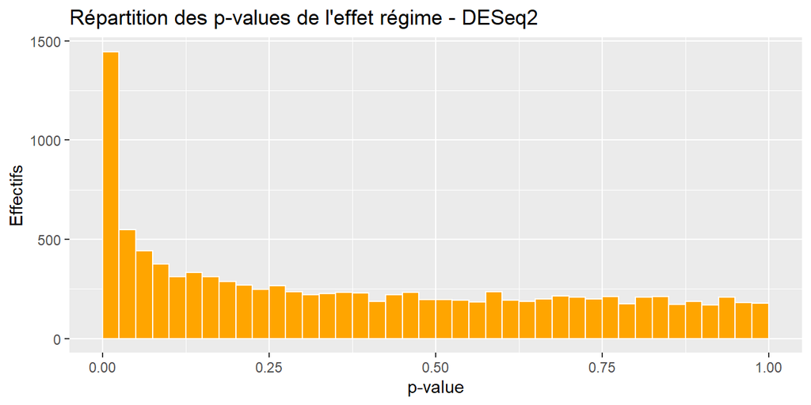

```r
data.frame(Pval=res$pvalue) %>% ggplot() + aes(x = Pval) +
  geom_histogram(fill="orange",bins=15,col="white",breaks=seq(from=0,to=1,by=0.025)) +
  ggtitle("Répartition des p-values de l'effet régime - DESeq2") + xlab("p-value") +
  ylab("Effectifs")
```

## Identification des gènes positifs

**Combien de gènes positifs ?**

```r
pval_deseq2 <- res$pvalue
positives_deseq2 <- pval_deseq2 <= 0.05
select <- which(positives_deseq2)
length(select)
```

```
[1] 1995
```

## 2.3 - Transformation des données de comptage

## Stabilisation de la variance

**Objectif** : transformer les données pour pouvoir utiliser le modèle linéaire classique

**Transformation logarithmique** : \(Z_{ij} = \mbox{log}_{2} ( Y_{0} + Y_{ij} )\)

```r
vsd <- vst(dds, blind=TRUE)
pseudo_counts <- assay(vsd)
head(pseudo_counts[,1:6],n=3) %>% kbl(caption="Table d'analyse de la déviance") %>%
  kable_paper(bootstrap_options = "striped", full_width = F)
```

|  | F10_G_B | F11_M_H | F13_G_H | F14_M_H | F15_G_B | F16_M_B |
| --- | --- | --- | --- | --- | --- | --- |
| CD69 | 7.72 | 8.20 | 8.17 | 8.48 | 7.68 | 8.46 |
| GOLGB1 | 11.07 | 11.54 | 11.06 | 11.04 | 10.45 | 10.90 |
| HCLS1 | 9.79 | 9.34 | 10.38 | 9.55 | 9.65 | 9.47 |

## Tests sur données transformées (package limma)

**Modèle d’analyse de la variance à l’échelle du génome**

```r
design = model.matrix(~Diet,data=covariates)
fit = lmFit(pseudo_counts,design)
head(fit$coefficients,n=3) %>%
  kbl(caption="Coefficients estimés") %>%
  kable_paper(bootstrap_options = "striped", full_width = F)
```

Coefficients estimés

|  | (Intercept) | DietH |
| --- | --- | --- |
| CD69 | 7.93 | 0.143 |
| GOLGB1 | 10.94 | 0.046 |
| HCLS1 | 9.72 | 0.279 |

## Tests de Fisher modérés (package limma)

**Test de Fisher pour le gène k**

\(F_{k}=\frac{\frac{\mbox{RSS}_{0k}-\mbox{RSS}_{k}}{\mbox{df}_{0k} - \mbox{df}_{k}}}{\frac{\mbox{RSS}_{k}}{\mbox{df}_{k}}}\)

**Test de Fisher modéré pour le gène k**

\(F^{*}_{k}=\frac{\frac{\mbox{RSS}_{0k}-\mbox{RSS}_{k}}{\mbox{df}_{0k} - \mbox{df}_{k}}}{(1-p_{k})s^{2}_{0} + p_{k} \frac{\mbox{RSS}_{k}}{\mbox{df}_{k}}}\)

**Méthode d’estimation de \(p_{k}\) et \(s^{2}_{0}\)** : empirical Bayes (fonction eBayes)

## Tests à l’échelle du génome (package limma)

```r
fit <- eBayes(fit)
pval_limma <- fit$p.value[,"DietH"]
pval_limma["LPCAT3"]
```

```
  LPCAT3
2.29e-08
```

**Gènes positifs**

```r
positives_limma <- pval_limma <= 0.05
sum(positives_limma)
```

```
[1] 1786
```

## Concordance limma - DESeq2

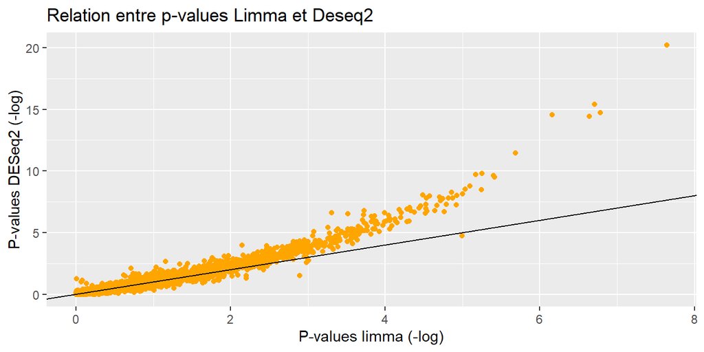

```r
data.frame(Limma=-log10(pval_limma),Deseq2=-log10(pval_deseq2)) %>% ggplot() +
  xlab("P-values limma (-log)") + ylab("P-values DESeq2 (-log)") +
  geom_point(aes(x=Limma,y=Deseq2),col="orange") +
  ggtitle("Relation entre p-values Limma et Deseq2") + geom_abline(intercept=0,slope=1)
```

## 3. Sélection de gènes

## Taille de l’effet à l’échelle du génome

**Densité de répartition des p-values** : \(f (p ) = \pi_{0} \mathbb{1}_{[0,1]} ( p ) + ( 1 - \pi_{0} ) f_{1} ( p )\) où \(\pi_{0}\) est la proportion de gènes non-impactés par l’effet testé.

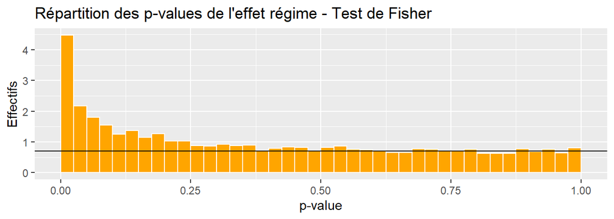

```r
data.frame(Pval=pval_limma) %>% ggplot() + aes(x = Pval,y=..density..) +
  geom_histogram(fill="orange",bins=15,col="white",breaks=seq(from=0,to=1,by=0.025)) +
  ggtitle("Répartition des p-values de l'effet régime - Test de Fisher") +
  xlab("p-value") + ylab("Effectifs") + geom_hline(yintercept=0.7)
```

## Taille de l’effet à l’échelle du génome (package fdrtool)

**Estimation du nombre de gènes non-impactés par l’effet testé**

```r
m <- length(pval_limma)
pi0 <- pval.estimate.eta0(pval_limma,diagnostic.plot=FALSE)
m0 <- m*pi0 ; m0
```

```
[1] 7524
```

## Tests simultanés à l’échelle du génome

**Procédure**

- Etape 1 - Pour le \(k\)ème gène, calcul de la p-value \(p_{k}\)
- Etape 2 - Choix d’un seuil sur la p-value : si \(p_{k} \leq t\) alors **le gène \(k\) est positif**

**Nombre de gènes positifs si \(t=0.05\)**

```r
positives_limma <- pval_limma <= 0.05
sum(positives_limma)
```

```
[1] 1786
```

## Faux positifs

**Définition** : un gène est **faux positif** si la procédure de test conclut que l’effet testé est significatif, alors que cet effet n’existe pas.

- Nombre de gènes positifs : \(\mbox{P}_{t}\)
- Nombre de gènes faux positifs : \(\mbox{V}_{t}\) (non-observable)
- Proportion de faux positifs : \(\mbox{FDP}_{t} = \frac{V_{t}}{P_{t}}\) (non-observable)

**Taux de faux positifs** : \(\mbox{FDR}_{t}=\mathbb{E} ( \mbox{FDP}_{t})\)

**Comment choisir le seuil \(t\) pour garantir \(\mbox{FDR}_{t} \leq 0.05\) ?**

## Estimation du FDR

Supposons que l’effet testé n’existe pas pour \(m_{0}\) gènes, parmi \(m\) gènes.

Pour chacun de ces \(m_{0}\) gènes, \(\mathbb{P} ( p_{k} \leq t) = t\)

Comme \(V_{t} = \# \left\{ k , p_{k} \leq t \right\}\), \(\mathbb{E} ( V_{t} ) = m_{0} t\).

**Estimation du FDR** : \(\widehat{FDR}_{t} = \frac{m_{0}t}{P_{t}}\)

**Exemple avec \(t=0.05\)**

```r
P <- sum(pval_limma <= 0.05)
FDR <- m0*0.05/P ; FDR
```

```
[1] 0.211
```

## Méthode de Benjamini-Hochberg

**Principe** : le seuil \(t\) est le plus grand possible pour lequel \(\widehat{\mbox{FDR}}_{t} \leq 0.05\)

**Sélection pour un contrôle du FDR au seuil de 0.05**

```r
fdr_limma <- pi0*p.adjust(pval_limma,method="BH")
sum(fdr_limma <= 0.05)
```

```
[1] 220
```

**Seuil de décision**

```r
p_sort <- sort(pval_limma)
fdr <- m0*p_sort/(1:m)
seuil <- max(p_sort[fdr<=0.05]) ; seuil
```

```
[1] 0.00145
```

## Sélection multi-critères (1/2, volcano plot)

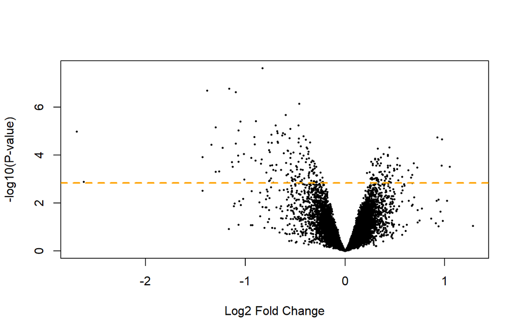

```r
volcanoplot(fit,coef=2)
abline(h = -log10(seuil),col = "orange",lty =2,lwd = 2)
```

## Sélection multi-critères (2/2)

**Gènes postifs et ayant un ratio d’expressions moyennes suffisamment grand**

```r
log_fc <- fit$coefficients[,"DietH"]
select <- (fdr_limma <= 0.05) & (abs(log_fc) > 1)
sum(select)
```

```
[1] 21
```

## Clustering des échantillons

[figure not shown]

```r
x = pseudo_counts[select,]
heatmap(x, Rowv = FALSE, col = rev(heat.colors(16)))
```

## Clustering des gènes sélectionnés

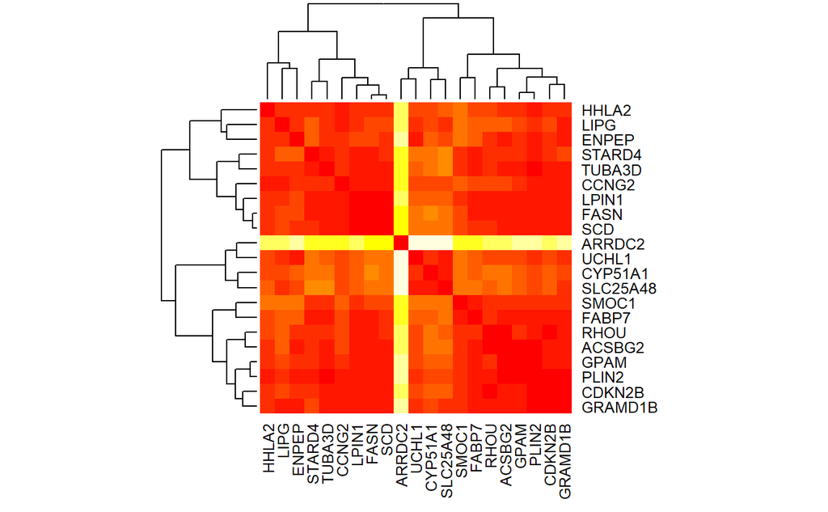

```r
heatmap(cor(t(x)), symm = TRUE, distfun = function(c) as.dist(1 - abs(c)),
        col = rev(heat.colors(16)),trace="none",dendrogram="col")
```